# PracticalMachineLearning_BarbellLifts

Claire Pierreclos

January 20, 2020

## Executive summary

Using devices such as Jawbone Up, Nike FuelBand, and Fitbit it is now possible to collect a large amount of data about personal activity relatively inexpensively. These type of devices are part of the quantified self movement – a group of enthusiasts who take measurements about themselves regularly to improve their health, to find patterns in their behavior, or because they are tech geeks. One thing that people regularly do is quantify how much of a particular activity they do, but they rarely quantify how well they do it. In this project,we will use data from accelerometers on the belt, forearm, arm, and dumbell of 6 participants. They were asked to perform barbell lifts correctly and incorrectly in 5 different ways. More information is available from the website here: http://groupware.les.inf.puc-rio.br/har (see the section on the Weight Lifting Exercise Dataset).

## Library

```r
library(caret)
library(rattle)
```

## Basic data analysis

```r
set.seed(1500)
setwd("C:/Users/mec/OneDrive - Trivadis AG/Data Science/R working directory/Cours 8 - Practical Machine Learning/Course project")
data_training <- read.csv("pml-training.csv")
data_testing <- read.csv("pml-testing.csv")
dim(data_training)
```

```
## [1] 19622   160
```

```r
index_Training <- createDataPartition(data_training$classe, p = 0.7, list = FALSE)
training <- data_training[index_Training, ]
testing <- data_training[-index_Training, ]
validating <- data_testing
dim(training)
```

```
## [1] 13737   160
```

The training dataset contains a data frame with 19622 observations on 160 columns. We split this dataset in a train dataset of 13737 observations and a test dataset of 5885 observations The other dataset will be the validation dataset of 20 observations.

## Cleaning data

```r
str(training)
```

```
## 'data.frame':    13737 obs. of  160 variables:
##  $ X                       : int  3 4 5 6 7 8 9 10 11 12 ...
##  $ user_name               : Factor w/ 6 levels "adelmo","carlitos",..: 2 2 2 2 2 2 2 2 2 2 ...
##  $ raw_timestamp_part_1    : int  1323084231 1323084232 1323084232 1323084232 1323084232 1323084232 1323084232 1323084232 1323084232 1323084232 ...
##  $ raw_timestamp_part_2    : int  820366 120339 196328 304277 368296 440390 484323 484434 500302 528316 ...
##  $ cvtd_timestamp          : Factor w/ 20 levels "02/12/2011 13:32",..: 9 9 9 9 9 9 9 9 9 9 ...
##  $ new_window              : Factor w/ 2 levels "no","yes": 1 1 1 1 1 1 1 1 1 1 ...
##  $ num_window              : int  11 12 12 12 12 12 12 12 12 12 ...
##  $ roll_belt               : num  1.42 1.48 1.48 1.45 1.42 1.42 1.43 1.45 1.45 1.43 ...
##  $ pitch_belt              : num  8.07 8.05 8.07 8.06 8.09 8.13 8.16 8.17 8.18 8.18 ...
##  $ yaw_belt                : num  -94.4 -94.4 -94.4 -94.4 -94.4 -94.4 -94.4 -94.4 -94.4 -94.4 ...
##  $ total_accel_belt        : int  3 3 3 3 3 3 3 3 3 3 ...
##  $ kurtosis_roll_belt      : Factor w/ 397 levels "","-0.016850",..: 1 1 1 1 1 1 1 1 1 1 ...
##  $ kurtosis_picth_belt     : Factor w/ 317 levels "","-0.021887",..: 1 1 1 1 1 1 1 1 1 1 ...
##  $ kurtosis_yaw_belt       : Factor w/ 2 levels "","#DIV/0!": 1 1 1 1 1 1 1 1 1 1 ...
```

[output cut: 86 more lines]

We can observe many NA values or blank values that we need to remove because they will not give to us any information. And the columns 1 to 7 contain information about people who did the test and timestamp so information not relevant for our model. We remove these columns for the 3 datasets: training, testing and validating.

```r
# Remove columns with too much NA or blank values
indexRemoveTraining <- which(colSums(is.na(training) |training=="")>0.9*dim(training)[1])
indexRemoveTesting <- which(colSums(is.na(testing) |testing=="")>0.9*dim(testing)[1])
indexRemoveValidating <- which(colSums(is.na(validating) |validating=="")>0.9*dim(validating)[1])
training <- training[,-indexRemoveTraining]
testing <- testing[,-indexRemoveTesting]
validating <- validating[,-indexRemoveValidating]
# Remove 7 first columns
training <- training[, -c(1:7)]
testing <- testing[, -c(1:7)]
validating <- validating[, -c(1:7)]
dim(training)
```

```
## [1] 13737    53
```

```r
dim(testing)
```

```
## [1] 5885   53
```

```r
dim(validating)
```

```
## [1] 20 53
```

We now have 53 columns for each datasets.

## Training - Classification Tree

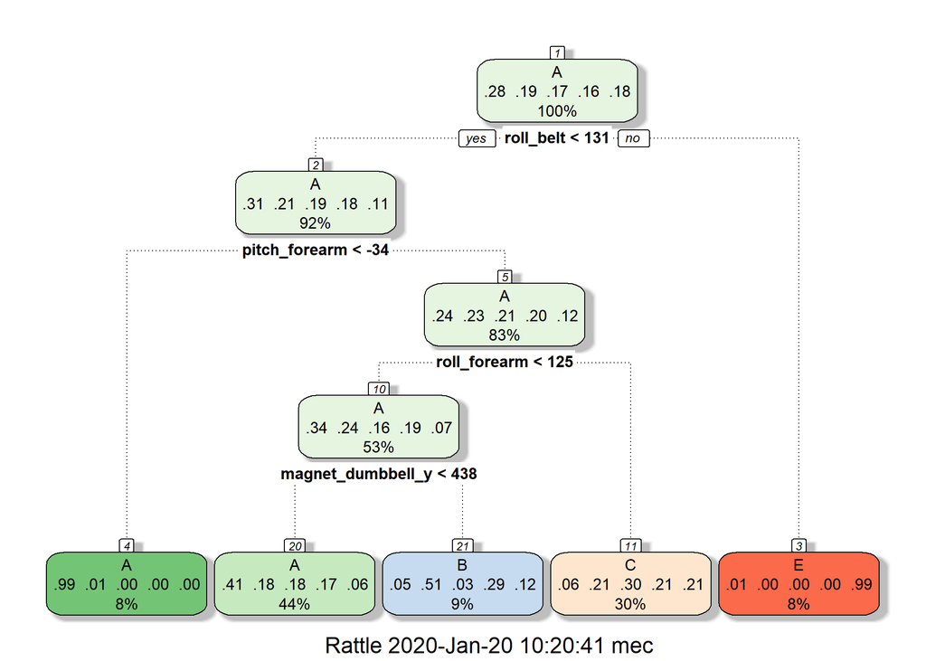

```r
model_ClassTree <- train(classe~., data=training, method="rpart", trControl=trainControl(method="cv", number=5))
fancyRpartPlot(model_ClassTree$finalModel)
```

```r
predict1_Train <- predict(model_ClassTree,newdata=testing)
matrix1_Train <- confusionMatrix(testing$classe,predict1_Train)
matrix1_Train$table
```

```
##           Reference
## Prediction    A    B    C    D    E
##          A 1516   17  136    0    5
##          B  470  305  364    0    0
##          C  478   18  530    0    0
##          D  441  177  346    0    0
##          E  158   57  379    0  488
```

```r
matrix1_Train$overall
```

```
##       Accuracy          Kappa  AccuracyLower  AccuracyUpper   AccuracyNull
##      0.4824129      0.3240153      0.4695727      0.4952706      0.5204758
## AccuracyPValue  McnemarPValue
##      1.0000000            NaN
```

We can remark the accuracy is low with the classification tree model: (around 48%). The out of sample error is 0.518. This means that the outcome class will not be predicted very well by the other predictors.

## Training - Random Forest

```r
model_RandForest <- train(classe~., data=training, method="rf", trControl=trainControl(method="cv", number=5),verbose=FALSE)
print(model_RandForest)
```

```
## Random Forest
##
## 13737 samples
##    52 predictor
##     5 classes: 'A', 'B', 'C', 'D', 'E'
##
## No pre-processing
## Resampling: Cross-Validated (5 fold)
## Summary of sample sizes: 10991, 10989, 10989, 10989, 10990
## Resampling results across tuning parameters:
##
##   mtry  Accuracy   Kappa
##    2    0.9903909  0.9878443
##   27    0.9899543  0.9872924
##   52    0.9851496  0.9812137
##
## Accuracy was used to select the optimal model using the largest value.
## The final value used for the model was mtry = 2.
```

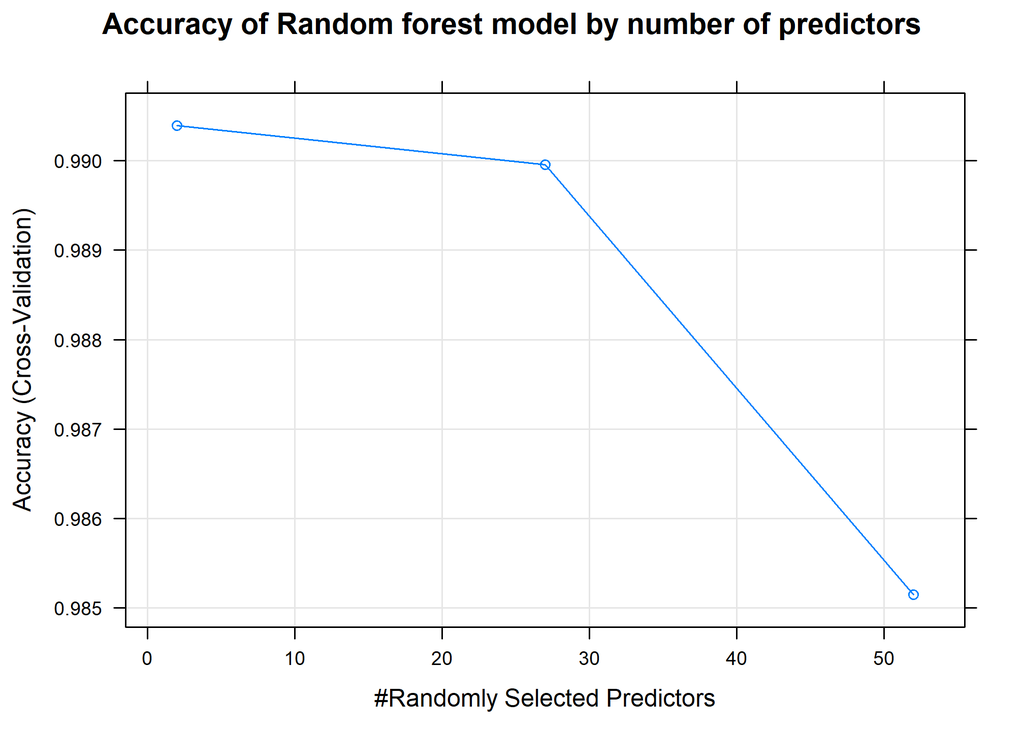

```r
plot(model_RandForest,main="Accuracy of Random forest model by number of predictors")
```

```r
predict2_Train <- predict(model_RandForest,newdata=testing)
matrix2_Train <- confusionMatrix(testing$classe,predict2_Train)
matrix2_Train$table
```

```
##           Reference
## Prediction    A    B    C    D    E
##          A 1674    0    0    0    0
##          B   12 1122    5    0    0
##          C    0   10 1016    0    0
##          D    0    0   27  937    0
##          E    0    0    0    0 1082
```

```r
matrix2_Train$overall
```

```
##       Accuracy          Kappa  AccuracyLower  AccuracyUpper   AccuracyNull
##      0.9908241      0.9883901      0.9880442      0.9930995      0.2864911
## AccuracyPValue  McnemarPValue
##      0.0000000            NaN
```

With the random forest, the accuracy is better (around 99%) using cross-validation with 5 steps (it can take several minutes to do the model). The out of sample error is 0.01.

## Training - Gradient Boosting

```r
model_GradBoost <- train(classe~., data=training, method="gbm", trControl=trainControl(method="cv", number=5),verbose=FALSE)
print(model_GradBoost)
```

```
## Stochastic Gradient Boosting
##
## 13737 samples
##    52 predictor
##     5 classes: 'A', 'B', 'C', 'D', 'E'
##
## No pre-processing
## Resampling: Cross-Validated (5 fold)
## Summary of sample sizes: 10991, 10989, 10991, 10989, 10988
## Resampling results across tuning parameters:
##
##   interaction.depth  n.trees  Accuracy   Kappa
##   1                   50      0.7528552  0.6866060
##   1                  100      0.8225215  0.7753041
##   1                  150      0.8563728  0.8182384
##   2                   50      0.8552811  0.8166855
##   2                  100      0.9082037  0.8838147
##   2                  150      0.9339733  0.9164510
##   3                   50      0.8980122  0.8708901
##   3                  100      0.9439466  0.9290706
##   3                  150      0.9598167  0.9491636
##
## Tuning parameter 'shrinkage' was held constant at a value of 0.1
##
## Tuning parameter 'n.minobsinnode' was held constant at a value of 10
## Accuracy was used to select the optimal model using the largest value.
## The final values used for the model were n.trees = 150,
##  interaction.depth = 3, shrinkage = 0.1 and n.minobsinnode = 10.
```

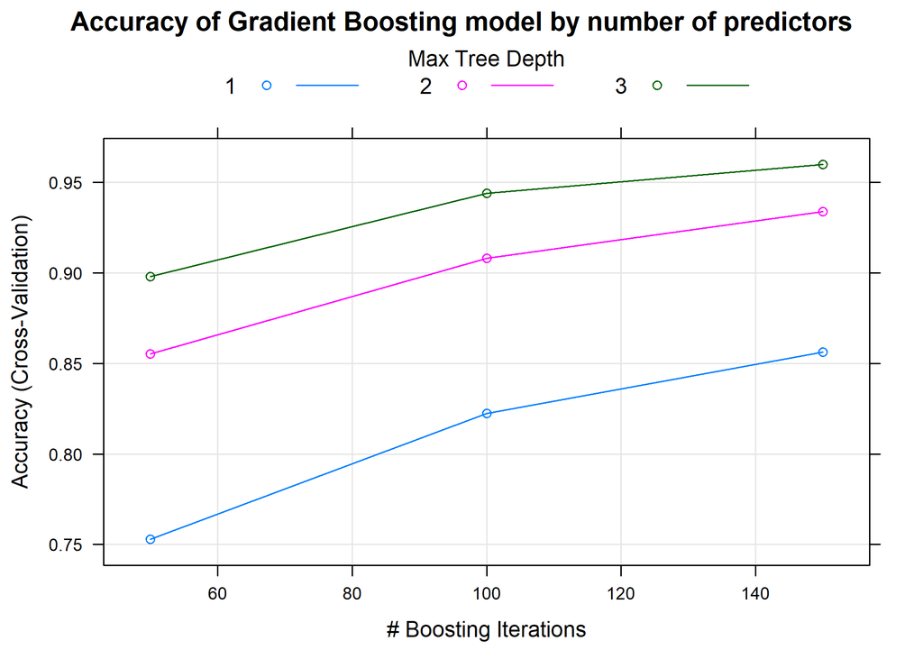

```r
plot(model_GradBoost,main="Accuracy of Gradient Boosting model by number of predictors")
```

```r
predict3_Train <- predict(model_GradBoost,newdata=testing)
matrix3_Train <- confusionMatrix(testing$classe,predict3_Train)
matrix3_Train$table
```

```
##           Reference
## Prediction    A    B    C    D    E
##          A 1645   17    7    4    1
##          B   51 1050   33    3    2
##          C    0   34  979   12    1
##          D    0    1   26  929    8
##          E    4   12   13   19 1034
```

```r
matrix3_Train$overall
```

```
##       Accuracy          Kappa  AccuracyLower  AccuracyUpper   AccuracyNull
##   9.578590e-01   9.466742e-01   9.524091e-01   9.628488e-01   2.888700e-01
## AccuracyPValue  McnemarPValue
##   0.000000e+00   9.095016e-09
```

With the Gradient Boostiong method, the accuracy is around 96%. The out of sample error is 0.042.

## Conclusion

```r
predict_Test <- predict(model_RandForest,newdata=validating)
predict_Test
```

```
##  [1] B A B A A E D B A A B C B A E E A B B B
## Levels: A B C D E
```